# Predicting College Students’ GPA through their Food and Cooking Preferences

Jingyi Huang, Yuchen Hu, Ante Bing and Dongyuan Song

2018/12/2

```r
library(tidyverse)
library(caret)
library(pROC)
library(plotROC)
library(pastecs)
library(ggcorrplot)
library(MASS)
library(leaps)
library(data.table)
library(psych)
library(nFactors)
library(reshape2)
library(randomForest)
library(ggridges)
```

Package Installation Warning: “Caret” requires several differen models. Unfortunately they could not be `library` at the beginning of Rmd. Please install them manually if there is any warning message when using caret to perform machine learning part.

Please specify your root here.

```r
knitr::opts_chunk$set(echo = TRUE, warning = FALSE, message = FALSE,
                      root.dir = "~/Desktop/BST260_2")
```

## Overview and Motivation

Motivation: It is widely acknowledged that students at colleges can sometimes be stressful. Most of them are eager to get good grades to better prepare themselves for future careers and academic developments. This is especially true for HCSPH students. Not only do we care about our grades, but we also care about our health. Sacrificing our health to achieve better grades cannot be a viable option. While a healthy diet is generally assumed to be important for good school performance, there has actually been little research on this topic.

Goal: we aim to explore the relationship between food preferences and GPA, as a way to highlight the importance of healthy diet and eating habits. More specifically, we looked at different categories of information such as: food choices, comfort food types, food calories, and how they relate to students’ GPA level. In addition, we built models to try to predict students’ GPA using their diet related information.

## Related Work

An article published in the Journal of School Health (2008) found that students who ate an adequate amount of fruit, vegetables, protein, fiber and other components of a healthy diet were significantly less likely to fail a literacy test. Similarly, Charles Basch, from Columbia University listed breakfast as one of the seven factors that can contribute to students’ performances in school (Journal of school health, 2011).

## Initial Questions

How food choices, comfort food types, food calories and etc. relate to students’ GPA level and weight?

## Data

The original dataset and its description can be found on Kaggle: https://www.kaggle.com/borapajo/food-choices. The original dataset contains 125 observations and 61 covariates. Since our data contains questionnaire answers, we used string processing method taught in class to start screening their text answers. Among the covariates, majority of them are categorical or ordinal. There is also a few covariates corresponding to the short answer questions in the questionnaire. We firstly removed the duplicated columns and converted integer type covariates into categorical type covariates. Then we manually deleted some observation values due to obvious data entry error. The cleaned version of the dataset is attached here: https://goo.gl/9XSRNf We also used NLP to illustrate the relationship between comfort/junk food and mental health (junk food and mental health with network analysis) using RShiny.

We first re-read in original data.

```r
dat <- read_csv("data/food_coded_clean.csv", na = "nan")
```

We notice that here is some duplicated columns. Filter out those columns.

```r
dat <- dat %>% dplyr::select( - ends_with("_1"))
```

For `chr` column, we remove them temporarily and leave it for NLP. For `int` column we convert them all into `fct` (although some of them are close to ordinary categorical data).

```r
weight_vector <- dat$weight
dat <- dat %>% dplyr::mutate_if(is.integer, as.factor) %>%
  dplyr::select_if(function(x) !is.character(x)) %>%
  dplyr::mutate(weight = as.numeric(weight_vector))
```

## Exploratory Analysis

We tried to use correlation plots which are usually used for continuous variables vs continuous variables to test collinearity. However, most of our covariates are categorical variables, so we decide to first use distribution plots and box plots to illustrate the relationship between our continuous dependent variable (GPA) and categorical independent variables (healthy feeling, fruit intake and etc).

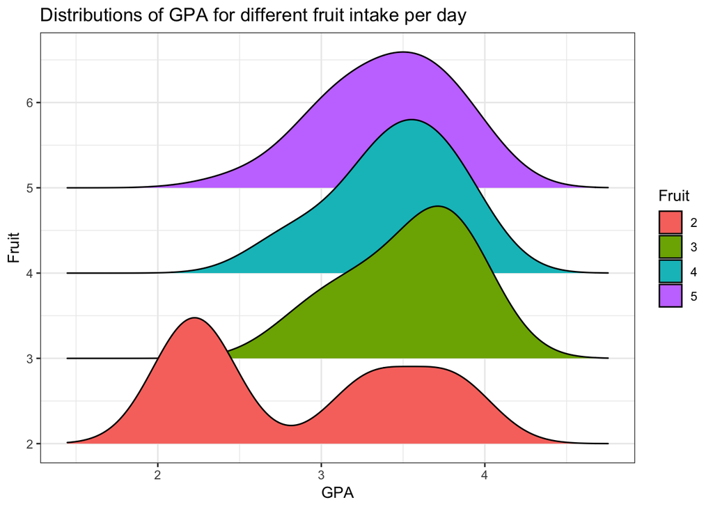

```r
food1=breakfast_clean <- readRDS("./data/breakfast_clean.rds")
Fruit=as.factor(food1$fruit_day)
food1 %>%
  #select(fruit_day,GPA)%>%
    ggplot(aes( y=fruit_day,x=GPA, group=as.factor(fruit_day),fill=Fruit))+
  geom_density_ridges()+
 theme_bw() +
    ylab("Fruit") +
    ggtitle("Distributions of GPA for different fruit intake per day")
```

Taking a moderate amount of fruit (Fruit intake=3) associates with larger GPA for most of the people (the peak of its distribution appears to be the most right-sided on the x-axis among other fruit intake scenarios).

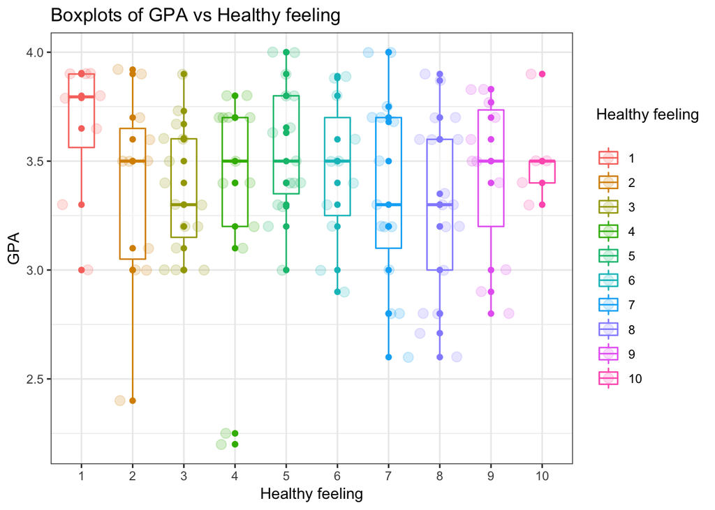

```r
dat %>%
  #select(healthy_feeling,GPA)%>%
    ggplot(aes( x=as.factor(healthy_feeling),y=GPA, color=as.factor(healthy_feeling))) +
    geom_boxplot(width=0.5, alpha=0.5) +
  geom_jitter(size=3,alpha=.2)+
  #geom_violin(width=1.4)+
  labs(color = "Healthy feeling\n")+
   geom_point(show.legend = FALSE) +
 theme_bw() +
    xlab("Healthy feeling") +
    ylab("GPA") +
    ggtitle("Boxplots of GPA vs Healthy feeling")
```

Health feeling =1 marks the people who are most confident that they are healthy. As we can see from the box plots, people who are the most confident about their health condition associated with higher GPA (the median is the highest among the 10 rating categories).

### Exploratory Factor Analysis

It could be noticed that we have a large set of covariates comparing to the number of observations we have. It’s possible that a lot of covariates in our datasets are highly correlated, and they might be jointly characterized by some latent factors.

```r
library(data.table)
library(psych)
library(nFactors)
library(reshape2)
library(tidyr)
#food <- read.csv("food_coded.csv",stringsAsFactors = FALSE)
#summary(food)
food <- read.csv("./data/food_coded_clean.csv", na = "nan")
food <- food %>% dplyr::select( - ends_with("_1"))
food <- food %>% dplyr::mutate_if(is.integer, as.factor) %>%
  dplyr::select_if(function(x) !is.character(x))
```

We start by filtering out all the numerical values in our dataframe. To decide the optimal number of factors to include in our model, we start by calculating the eigenvalues and ploting the scree plot.

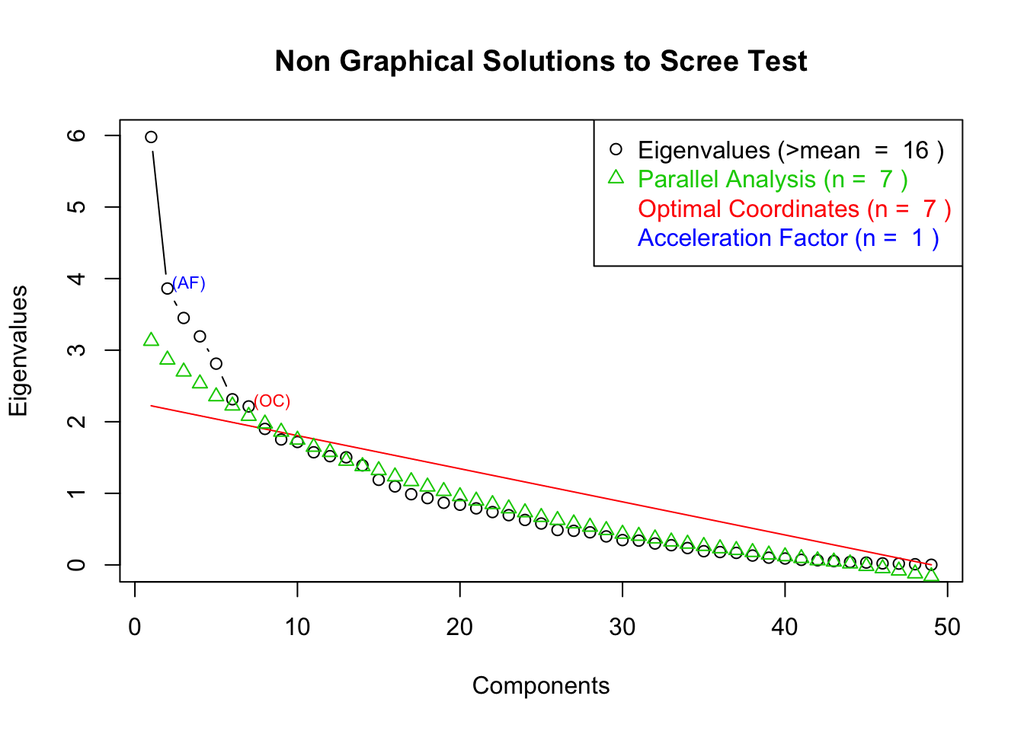

```r
food_numeric <- food[,-c(8,9,14,17,25,26,29,35,36,43,45,57)]
food_numeric <- food_numeric[complete.cases(food_numeric), ] %>%
  lapply(function(x) as.numeric(as.character(x)))
food_numeric <- as.data.frame(do.call(cbind, food_numeric))
ev <- eigen(cor(food_numeric))
ap <- parallel(subject=nrow(food_numeric),var=ncol(food_numeric),
               rep=100,cent=.05)
nS <- nScree(x=ev$values, aparallel=ap$eigen$qevpea)
plotnScree(nS)
```

It seems that we may choose to include 7 factors in our model.

```r
fa_numeric <- fa(food_numeric, 7)
summary(fa_numeric)
```

```
##
## Factor analysis with Call: fa(r = food_numeric, nfactors = 7)
##
## Test of the hypothesis that 7 factors are sufficient.
## The degrees of freedom for the model is 854  and the objective function was  28.53
## The number of observations was  58  with Chi Square =  1003.38  with prob <  0.00029
##
## The root mean square of the residuals (RMSA) is  0.07
## The df corrected root mean square of the residuals is  0.08
##
## Tucker Lewis Index of factoring reliability =  0.513
## RMSEA index =  0.126  and the 10 % confidence intervals are  0.039 NA
## BIC =  -2464.24
```

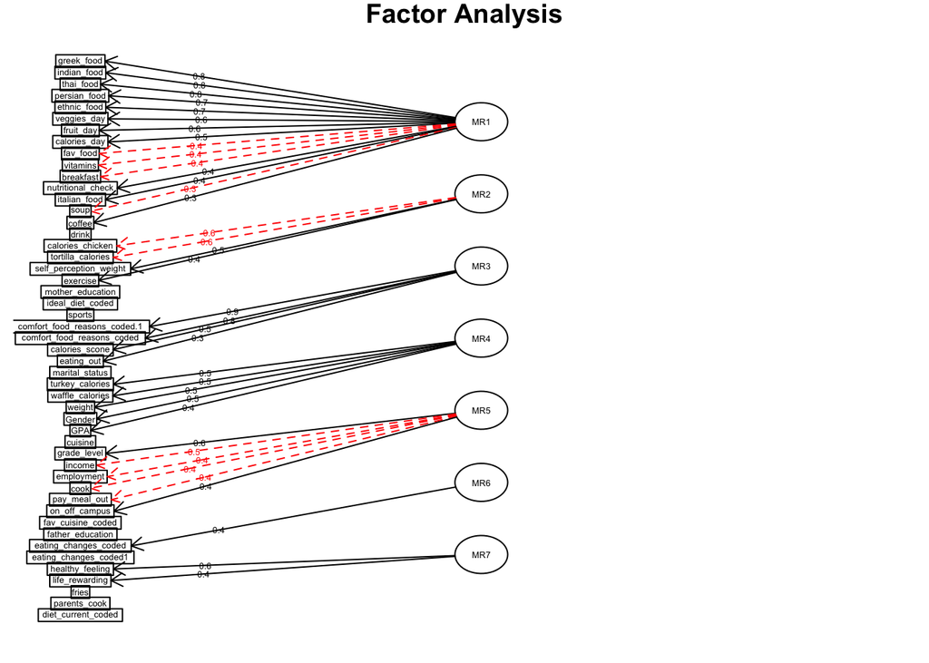

```r
fa.diagram(fa_numeric,side=1)
```

The dimension could thus be reduced by replacing the covariates by the factor loadings. According to the interpretation of the variables, we define the 7 factors as “food_choices”, “eating_habits”, “comfort_food”, “calories_guess”, “social_background”, “demographic_information”, and “life_feeling” respectively.

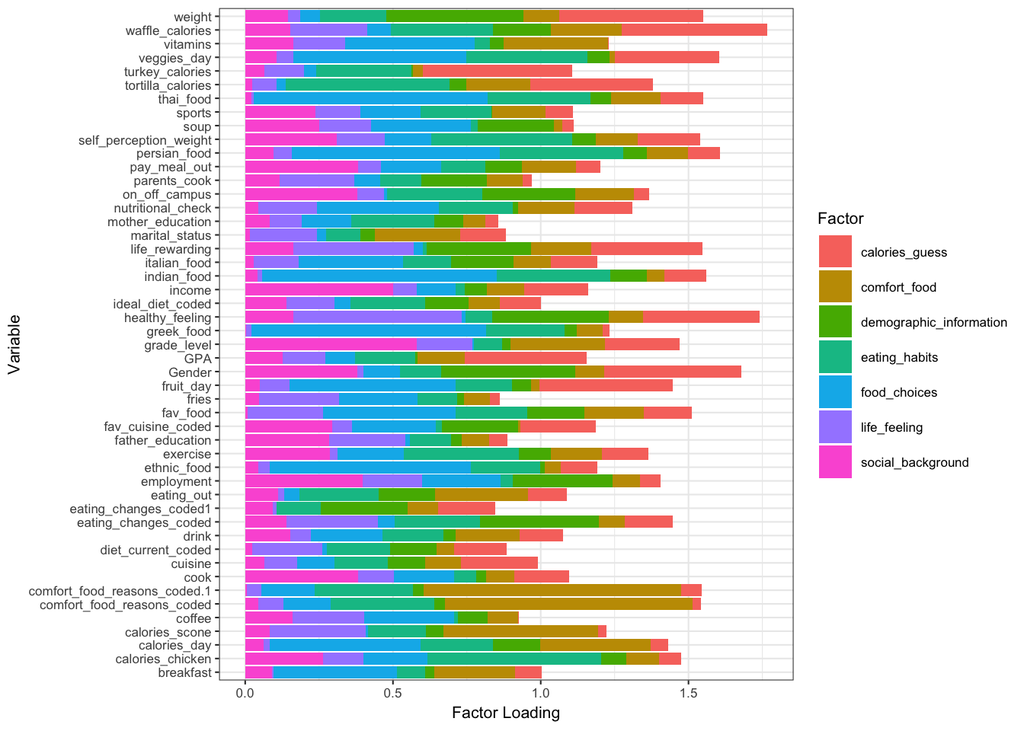

```r
# plot the result
gathering <- as.data.frame(matrix(nrow = dim(food_numeric)[2], ncol =7))
gathering$Variable <- colnames(food_numeric)
for (i in 1:7) {
  for (j in 1:dim(food_numeric)[2]) {
    gathering[j, i] <- fa_numeric$loadings[j, i]
  }
}
colnames(gathering) <- c("food_choices", "eating_habits", "comfort_food",
                         "calories_guess", "social_background",
                         "demographic_information", "life_feeling", "Variable")
gathering <- gathering %>% gather("Factor", "Value", 1:7)
ggplot(gathering, aes(Variable, abs(Value), fill=Factor)) +
  geom_bar(stat="identity") + coord_flip() +
  ylab("Factor Loading") +
  theme_bw(base_size=8)
```

## Word cloud and exploration

As an open-ended questionnaire, there are also lots of text variables besides the numerical and categorical variables. In order to fully exploit the dataset, we developed a shiny app allowing us to visualize how people react to those questions by characterizing the most frequent words in those variables. To facilitate comparison, we also filtered out some meaningless words such as ‘I’, ‘and’, ‘my’.

One could choose from the sidebar which variable he would like to view, and it’s also possible to adjust the minimum frequency of the word cloud for better visual experience. The higher the minimum frequency, the sparser the word cloud would be.

```r
library(wordcloud)
library(tidyverse)
library(stringr)
library(tidytext)
library(shiny)

#food <- read.csv("food_coded.csv",stringsAsFactors = FALSE)

food_health <- list("Comfort Food" = "comfort_food",
              "Reason for Having Comfort Food" = "comfort_food_reasons",
              "Current Diet" = "diet_current",
              "Change in Eating Habits" = "eating_changes",
              "Food used to have in childhood" = "food_childhood",
              "Perception of Healthy Meal" = "healthy_meal",
              "Ideal diet" = "ideal_diet",
              "Dinners to Have with Friends" = "meals_dinner_friend",
              "Types of Sports" = "type_sports")

getWords <- function(variable) {
  if (!(variable %in% food_health))
    stop("Unknown variable")

  text <- food[,names(food) == variable] %>%
    str_to_lower() %>%
    str_split("\"\'(),|\\|/| ") %>%
    unlist()
  text <- text[!text %in% c('','and','i','when','am','or','they','i\'m','my','usually','are','a','/')]}

u <- shinyUI(fluidPage(
  titlePanel("Word Cloud for text variables in our dataset"),
  sidebarLayout(
    sidebarPanel(
      selectInput("selection", "Choose a variable:",
                  choices = food_health),
      hr(),
      sliderInput("freq",
                  "Minimum Frequency:",
                  min = 1,  max = 20, value = 5)),
    mainPanel(plotOutput("plot")))))

s <- shinyServer(
  function(input, output, session) {
  terms <- reactive({getWords(input$selection)})

  wordcloud_rep <- repeatable(wordcloud)
  output$plot <- renderPlot({
    v <- terms()
    wordcloud_rep(v, scale=c(4,0.5),
                  min.freq = input$freq,
                  colors=brewer.pal(8, "Dark2"))})})

shinyApp(ui = u,server = s)
```

## Junk food and mental health with network analysis

Food is closely related to one’s emotional mode and could in turn largely affect one’s emotion. There are thousands of articles studying the relationship between food, gut bacteria and mental health. Here we only focus on the two variables available in our dataset, `comfort_food` and `comfort_food_reasons`, aiming to provide some insight towards the relationship through text processing and network analysis.

By choosing `Radical` from the tab, one could view the hierarchical tree diagram with the Reingold & Tilford’s Tidier Layout (Reingold & Tilford, 1981). The name of the variable would be magnified when the cursor is pointed to it. `Fruchterman-Reingold` gives the force-directed diagram with the Fruchterman-Reingold layout (Fruchterman & Reingold, 1991). For both of the diagrams, one could adjust the sparsity to achieve better visualization effect.

```r
library(shiny)
library(NLP)
library(tm)
library(igraph)
library(networkD3)

u <- shinyUI(fluidPage(
  titlePanel("Junk food and mental health with network analysis"),

  sidebarLayout(
    position = "left",
    sidebarPanel(
      h2("Controls"),
      sliderInput("sparse", "Sparsity:", 0.9, 1, 0.994,0.002),
      numericInput("fmrseed", "F-R Seed:", 1234, 1, 10000, 1)
    ),
    mainPanel(
      h2("Network Graphs"),
      tabsetPanel(
        tabPanel("Radial",radialNetworkOutput("radial")),
        tabPanel("Fruchterman-Reingold", plotOutput("fmr"))
      )
  )
))
)

data <- food[,names(food) %in% c("comfort_food","comfort_food_reasons")]
data <- do.call(paste, c(food[c("comfort_food", "comfort_food_reasons")], sep = ". ")) %>% str_to_lower()

s <- shinyServer(
  function(input, output)
  {
    r_stats_text_corpus <- Corpus(VectorSource(data))

    matadj <- reactive({
      tdm <-TermDocumentMatrix(r_stats_text_corpus, control = list(wordLenghts = c(1, Inf)))
      idx <-which(dimnames(tdm)$Terms == "call") ##change the terms to be searched
      tdm2 <- removeSparseTerms(tdm, sparse = input$sparse)
      m2 <- as.matrix(tdm2)
      m2[m2 >= 1] <- 1
      m2 <- m2 %*% t(m2) ##Adjaceny Matrix - how often words co-occur in a sentence
      m2
    })

    fit <- reactive({
      fit <- hclust(dist(matadj()))
    })

    fmrlayout <- reactive({
      set.seed(input$fmrseed)
      g <- graph.adjacency(matadj(), weighted = T, mode = "undirected")
      g <- simplify(g)
      V(g)$label <- V(g)$name
      V(g)$degree <- degree(g)
      layout <- layout.fruchterman.reingold(g)
      rv <- list()
      rv$g <- g
      rv$layout <- layout
      rv
    })

    radialnet <- reactive({
      set.seed(input$fmrseed)
      radial <- as.radialNetwork(fit())
    })

    ###Different Social Network Graphics

    #Radial Network
    output$radial <- renderRadialNetwork({
      radialNetwork(radialnet())
    })
    output$radial1 <- renderRadialNetwork({
      radialNetwork(radialnet())
    })

    # Fruchterman-Reingold Network
    output$fmr <- renderPlot({
      rv <- fmrlayout()
      plot(rv$g, layout = rv$layout)
    })
    output$fmr1 <- renderPlot({
      rv <- fmrlayout()
      plot(rv$g, layout = rv$layout)
    })
  }
)

shinyApp(ui = u,server = s)
```

## Interpretation Model

For convenience reasons, we first created dummy variables for all of the categorical covariates in the dataset. We then removed the highly correlated covariates using cutoff value at 0.9. As for missing values, we couldn’t remove the missing rows because there were less than half of the observations are completed cases. We decided to use median imputations since considering the sample size, it is also inappropriate to assume other types of underlying distributions for the observed values.

```r
dat_dummy <- dummyVars(" ~ .", data = dat, fullRank = T)
#head(dat_dummy)
dat_trsf <- data.frame(predict(dat_dummy, newdata = dat))
nzv <- nearZeroVar(dat_trsf, saveMetrics= TRUE)
nzv[nzv$nzv,]
```

|  | freqRatio | percentUnique | zeroVar | nzv |
| --- | --- | --- | --- | --- |
| comfort_food_reasons_coded.4 | 34.33333 | 1.6 | FALSE | TRUE |
| comfort_food_reasons_coded.5 | 25.50000 | 1.6 | FALSE | TRUE |
| comfort_food_reasons_coded.6 | 105.00000 | 1.6 | FALSE | TRUE |
| comfort_food_reasons_coded.7 | 34.33333 | 1.6 | FALSE | TRUE |
| comfort_food_reasons_coded.8 | 105.00000 | 1.6 | FALSE | TRUE |
| comfort_food_reasons_coded.9 | 20.20000 | 1.6 | FALSE | TRUE |
| cuisine.3 | 35.00000 | 1.6 | FALSE | TRUE |
| cuisine.4 | 35.00000 | 1.6 | FALSE | TRUE |
| cuisine.5 | 107.00000 | 1.6 | FALSE | TRUE |
| cuisine.6 | 53.00000 | 1.6 | FALSE | TRUE |

[output cut: 25 more lines]

```r
#Unluckily, there are some near zero-variance factors. We remove them.
nzv <- nearZeroVar(dat_trsf)
dat_trsf_nz <- dat_trsf[, -nzv]
descrCor <- cor(dat_trsf_nz, use = "pairwise.complete.obs")
#summary(descrCor[upper.tri(descrCor)])
# remove highly correlated columns
highlyCorDescr <- findCorrelation(descrCor, cutoff = .9)
dat_trsf_nz <- dat_trsf_nz[,-highlyCorDescr]
descrCor2 <- cor(dat_trsf_nz, use = "pairwise.complete.obs")
#summary(descrCor2[upper.tri(descrCor2)])
# median imputation
prepo <- preProcess(dat_trsf_nz, method = c("medianImpute"), na.remove = TRUE)
imp_dat_trsf_nz <- predict(prepo, dat_trsf_nz)
```

We did our model fitting under two scenarios, one is to consider GPA as a continuous outcome, while the other is to consider it as a categorical outcome. For the continuous case, we utilized LASSO regression to do feature selection.

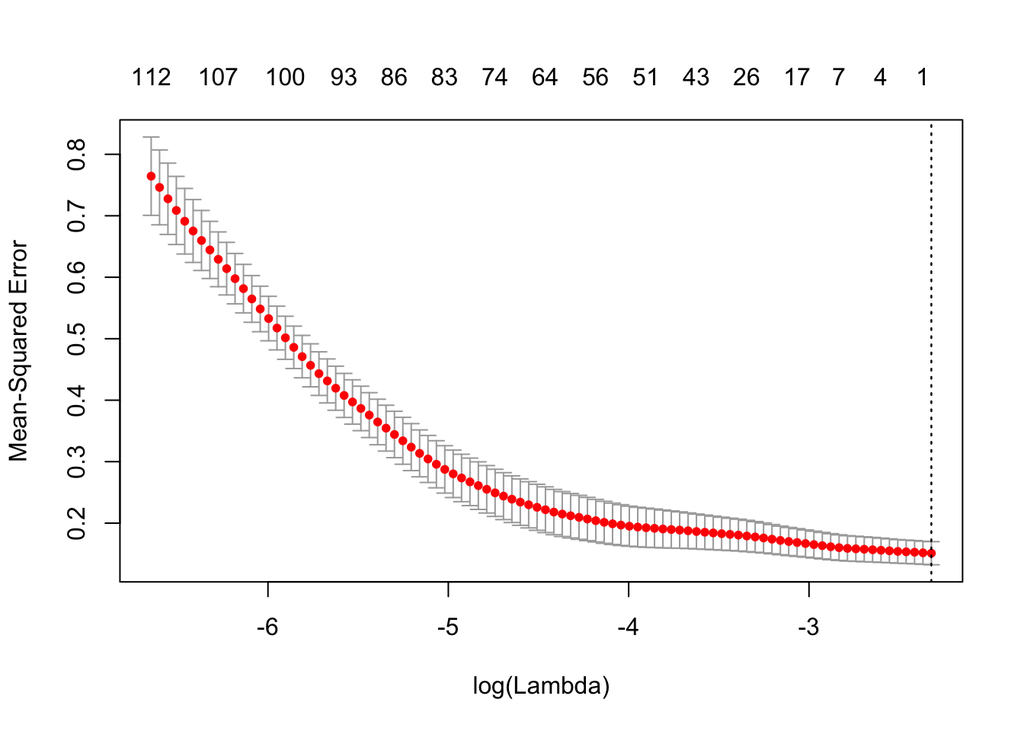

```r
# LASSO
library(glmnet)
c_cv <- cv.glmnet(as.matrix(imp_dat_trsf_nz[-1]), as.matrix(imp_dat_trsf_nz[,1]), standardize = T, alpha = 1)
tmp_coeffs <- coef(c_cv, s = "lambda.min")
#tmp_coeffs
plot(c_cv)
```

However, none of the covariates were selected into the final model (Please see the HTML file for detail). Then, we used stepwise selection using BIC as criteria.

```r
null <- lm(GPA~1,data=imp_dat_trsf_nz)
full <- lm(GPA~.,data=imp_dat_trsf_nz)
step_leap <- step(null, scope=list(lower=null, upper=full), direction="both", k = log(125), trace = 0)
summary(step_leap)
```

```
##
## Call:
## lm(formula = GPA ~ father_education.5 + thai_food.5 + greek_food.2 +
##     fav_cuisine_coded.1, data = imp_dat_trsf_nz)
##
## Residuals:
##      Min       1Q   Median       3Q      Max
## -1.31572 -0.21147  0.01993  0.23966  0.72958
##
## Coefficients:
##                     Estimate Std. Error t value Pr(>|t|)
## (Intercept)          3.31147    0.05377  61.591  < 2e-16 ***
## father_education.5  -0.24104    0.07551  -3.192  0.00180 **
## thai_food.5          0.21973    0.06998   3.140  0.00213 **
## greek_food.2         0.25425    0.10176   2.499  0.01382 *
## fav_cuisine_coded.1  0.14887    0.06322   2.355  0.02016 *
## ---
## Signif. codes:  0 '***' 0.001 '**' 0.01 '*' 0.05 '.' 0.1 ' ' 1
##
## Residual standard error: 0.3515 on 120 degrees of freedom
## Multiple R-squared:  0.1888, Adjusted R-squared:  0.1618
## F-statistic: 6.983 on 4 and 120 DF,  p-value: 4.349e-05
```

Four covariates turned out to be statistically significant (p < 0.05). Those covariates are: 1. if students’ father went to graduate school 2. if students are very likely to eat Thai food when its available 3. if students are unlikely to eat Greek food when it is available 4. if students’ favorite food are either Italian, French or Greek food.

For the categorical case, we separated GPA into two categories: below 3.5 and above 3.5. We selected this cutoff value because the median GPA value is around 3.5. Similarly, we carried out both LASSO and step-wise selections.

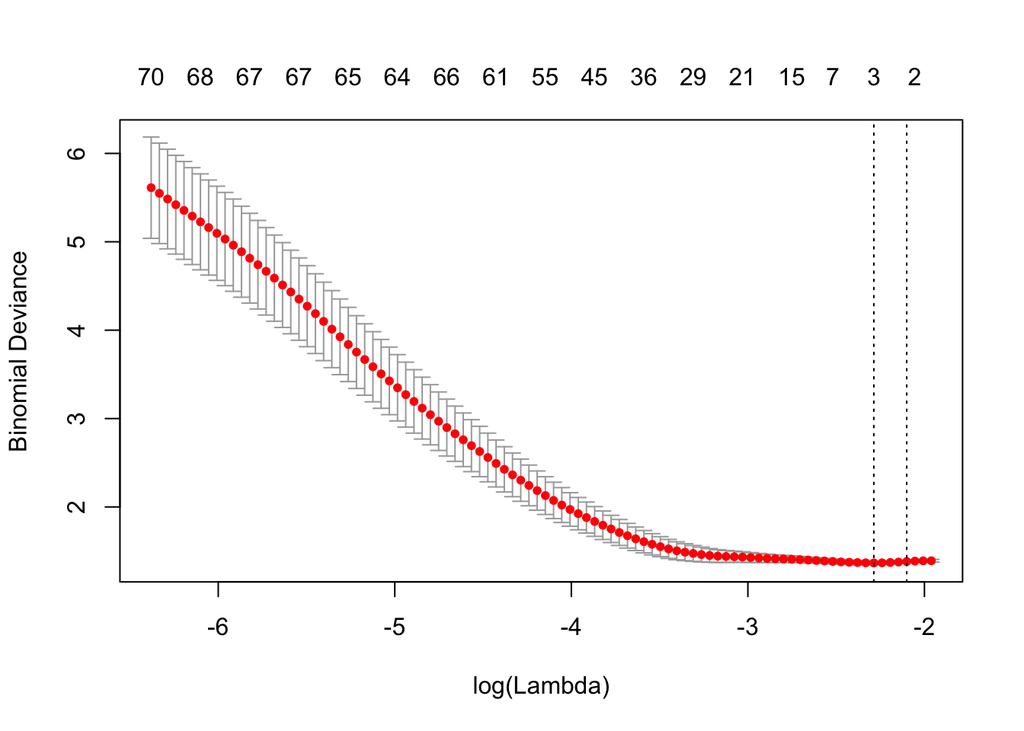

```r
dat_trsf_nz_im_c <- imp_dat_trsf_nz %>% dplyr::mutate(GPA = GPA >= 3.5, GPA = as.factor(GPA))
# LASSO
c_cv <- cv.glmnet(as.matrix(dat_trsf_nz_im_c[-1]), as.matrix(dat_trsf_nz_im_c[,1]),family="binomial", standardize = T, alpha = 1)
tmp_coeffs <- coef(c_cv, s = "lambda.min")
#tmp_coeffs
plot(c_cv)
```

LASSO returned three covariates: 1. if students’ father went to graduate school 2. if students’ father went to college 3. if students exercise exactly once per week.

```r
# step wise
null <- glm(GPA~1,data=dat_trsf_nz_im_c, family = binomial)
full <- glm(GPA~.,data=dat_trsf_nz_im_c, family=binomial)
stepmodel = step(null,scope=list(lower=formula(null),upper=formula(full)),
 direction="both", k=log(125), trace = 0)
summary(stepmodel)
```

```
##
## Call:
## glm(formula = GPA ~ exercise.3 + father_education.5 + ethnic_food.5 +
##     nutritional_check.3 + greek_food.2 + soup.2 + eating_changes_coded.1.2 +
##     on_off_campus.3 + income.6 + fav_cuisine_coded.1, family = binomial,
##     data = dat_trsf_nz_im_c)
##
## Deviance Residuals:
##     Min       1Q   Median       3Q      Max
## -2.3871  -0.5274   0.1091   0.6765   2.0206
##
## Coefficients:
##                          Estimate Std. Error z value Pr(>|z|)
## (Intercept)               -2.8800     0.7543  -3.818 0.000135 ***
## exercise.3                -3.8288     1.3572  -2.821 0.004785 **
## father_education.5        -2.0333     0.6699  -3.035 0.002405 **
## ethnic_food.5              3.0110     0.7356   4.094 4.25e-05 ***
## nutritional_check.3        2.3315     0.8519   2.737 0.006201 **
## greek_food.2               3.6723     1.0001   3.672 0.000241 ***
## soup.2                     2.3720     0.7788   3.046 0.002322 **
## eating_changes_coded.1.2   2.8588     0.9661   2.959 0.003086 **
## on_off_campus.3            3.2800     1.0992   2.984 0.002846 **
## income.6                   1.4313     0.6088   2.351 0.018731 *
## fav_cuisine_coded.1        1.2271     0.5271   2.328 0.019917 *
## ---
## Signif. codes:  0 '***' 0.001 '**' 0.01 '*' 0.05 '.' 0.1 ' ' 1
##
## (Dispersion parameter for binomial family taken to be 1)
##
##     Null deviance: 172.32  on 124  degrees of freedom
## Residual deviance: 103.78  on 114  degrees of freedom
## AIC: 125.78
##
## Number of Fisher Scoring iterations: 6
```

Step-wise selections returned more than a few significant covariates. Some of the highly significant ones include: 1. if the students are highly likely to eat ethnic food 2. if the students are unlikely to eat Greek food when it is avaliable 3. if the students have been eating more since they got into college.

In general, if we only focus on continuous GPA, the covariate: “if students’ father went to graduate school” is an interesting case. The reason is that this covariate is negatively related to students’ GPA.

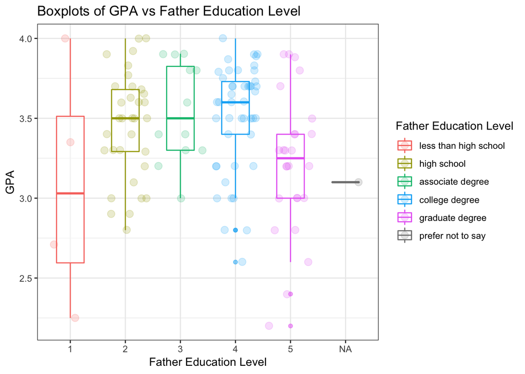

```r
food <- dat
food %>%
  ggplot(aes(x=as.factor(father_education),y=GPA, color=as.factor(father_education)))+ geom_boxplot(width=0.5,  alpha=0.5)+ xlab("Father Education Level") + geom_jitter(size=3,alpha=.2) +
    ylab("GPA") +
    ggtitle("Boxplots of GPA vs Father Education Level") + theme_bw() +labs(color='Father Education Level') +scale_color_hue(labels = c("less than high school", "high school", "associate degree", "college degree", "graduate degree", "prefer not to say"))
```

Additionally, if we only consider categorical GPA as the outcome, another interesting case is students’ love toward ethnic food, which seems to be positively related to GPA.

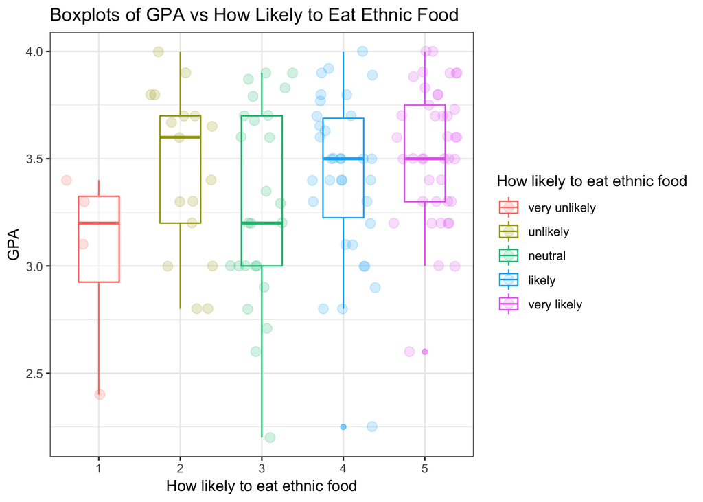

```r
food <- dat
food %>%
  ggplot(aes(x=as.factor(ethnic_food),y=GPA, color=as.factor(ethnic_food)))+ geom_boxplot(width=0.5,  alpha=0.5)+ xlab("How likely to eat ethnic food") + geom_jitter(size=3,alpha=.2) +
    ylab("GPA") +
    ggtitle("Boxplots of GPA vs How Likely to Eat Ethnic Food") + theme_bw() +labs(color='How likely to eat ethnic food') +scale_color_hue(labels = c("very unlikely", "unlikely", "neutral", "likely", "very likely", "N/A"))
```

Although the sample size is small, we can still detect some trend here. Since students’ love toward ethnic food might be related to their background, culture or heritage, it is not surprising to identify a trend here.

To further looking into the available variables, we also performed random forest to calculate variable importance.

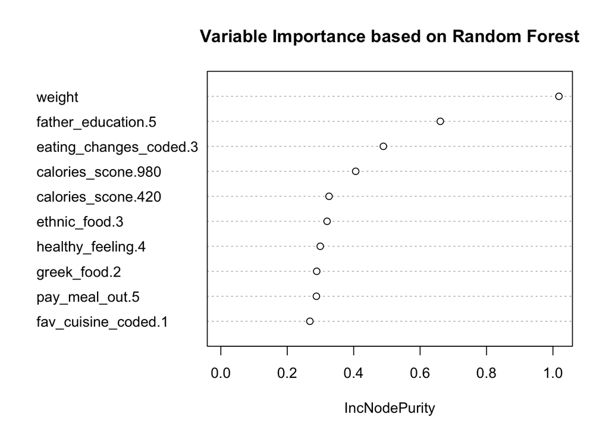

```r
set.seed(1234)
fit_rf <- randomForest(GPA ~ .,data = imp_dat_trsf_nz)
varImpPlot(fit_rf, type = 2 , main = "Variable Importance based on Random Forest",n.var = 10)
```

Weight is the variable that grabbed our attention. We are not sure why it was not picked up through step-wise selection or LASSO. We plotted GPA vs Weight to look into this problem.

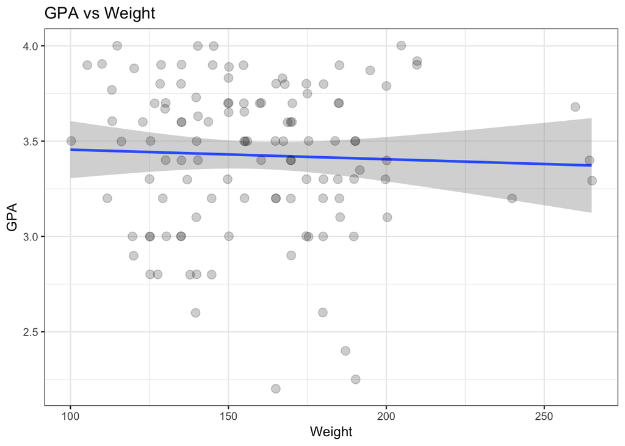

```r
food %>%
  ggplot(aes(x=as.numeric(weight),y=as.numeric(GPA)))+ geom_smooth(method='lm',formula=y~x)+ xlab("Weight") + geom_jitter(size=3,alpha=.2) +
    ylab("GPA") +
    ggtitle("GPA vs Weight") + theme_bw()
```

## Prediction Model

One main interest is to use our food data to predict GPA. From Interpretation model, we find that the association between GPA and other variables is quite weak. However, can we use some machine learning model, especially non-linear model, such as KNN and SVM, to predict GPA effectively?

### Data Preprocessing

We have performed standard data preprocessing in last step. We now want to create training data and test data. Split data into train set and test set. The size of test data is 20% of original data.

```r
dat_trsf_nz_im <- imp_dat_trsf_nz
set.seed(123)
trainIndex <- createDataPartition(dat_trsf_nz_im$GPA, p = .8,
                                  list = FALSE,
                                  times = 1)
x.t <- dat_trsf_nz_im
y.t <- dat_trsf_nz_im[, "GPA"]
y.train <- y.t[trainIndex]
y.test <- y.t[-trainIndex]
x.train <- x.t[trainIndex,]
x.test <- x.t[-trainIndex,]
x <- x.train
y <- y.train
```

### Continuous GPA

We first treat GPA as a continuous variable. We tried several “regression” model: “knn”, “glm”, “ridge”, “lasso”, “rf”, “svmRadial”.

```r
set.seed(123)
models = c("knn", "glm", "ridge", "lasso", "rf", "svmRadial")
train.control = trainControl(method = "repeatedcv", number = 5, repeats = 10, verbose = FALSE)
n_models = length(models)
for (m in 1:n_models) {
    fit = train(GPA ~ ., method = models[m], trControl = train.control, data = x)
    cat(c(models[m], "\n"))
    cat(c("Train RMSE", round(getTrainPerf(fit)$TrainRMSE, 3), "\t"))
    pre = predict(fit, newdata = x.test, type = "raw")
    mse_test <- sqrt(mean((y.test - pre)^2))
    cat(c("Test RMSE", round(mse_test, 3), "\n"))
}
```

```
## knn
## Train RMSE 0.395     Test RMSE 0.461
## glm
## Train RMSE 9.839     Test RMSE 3.397
## ridge
## Train RMSE 0.549     Test RMSE 0.573
## lasso
## Train RMSE 0.399     Test RMSE 0.42
## rf
## Train RMSE 0.371     Test RMSE 0.424
## svmRadial
## Train RMSE 0.376     Test RMSE 0.428
```

We also use the naive mean of training set to calculate RMSE on test set.

```r
sqrt(mean((y.test - mean(y.train))^2))
```

```
## [1] 0.423255
```

### Binary GPA

Since the continuous outcome might be difficult to predict, we might consider converting it into binary outcome. We check if the binary outcome is more predictable.

We first generate binary outcome data.

```r
dat_trsf_nz_im_c <- dat_trsf_nz_im %>% dplyr::mutate(GPA = GPA >= 3.5, GPA = as.factor(GPA))
x.c <- dat_trsf_nz_im_c
y.c <- dat_trsf_nz_im_c[, "GPA"]
y.train.c <- y.c[trainIndex]
y.test.c <- y.c[-trainIndex]
x.train.c <- x.c[trainIndex,]
x.test.c <- x.c[-trainIndex,]
x.c <- x.train.c
y.c <- y.train.c
```

We tried several “classification” models: “knn”, “rf”, “glm”, “lda”, “svmLinear”, “svmRadial”.

```r
set.seed(123)
models = c("knn", "rf", "glm", "lda",  "svmLinear", "svmRadial")
train.control = trainControl(method = "repeatedcv", number = 10, repeats = 10, verbose = FALSE)
n_models = length(models)
for (m in 1:n_models) {
    fit = train(GPA ~ ., method = models[m], trControl = train.control, data = x.c)
    cat(c(models[m], "\n"))
    cat(c("Train Accuracy", round(getTrainPerf(fit)$TrainAccuracy, 3), "\t"))
    pre = predict(fit, newdata = x.test.c, type = "raw")
    acc_test <- (mean(y.test.c == pre))
    cat(c("Test Accuracy", round(acc_test, 3), "\n"))
}
```

```
## knn
## Train Accuracy 0.502     Test Accuracy 0.391
## rf
## Train Accuracy 0.532     Test Accuracy 0.478
## glm
## Train Accuracy 0.483     Test Accuracy 0.522
## lda
## Train Accuracy 0.552     Test Accuracy 0.478
## svmLinear
## Train Accuracy 0.531     Test Accuracy 0.609
## svmRadial
## Train Accuracy 0.559     Test Accuracy 0.478
```

All results seem to be not quite satisfying; we check further in the ROC curves. We chose “glm”, “knn”, “rf” and “lda” (“svm” does not provide ROC curve). Note here we did not add “SVM” since it does not have a ROC curve.

```r
set.seed(123)
fit_knn <- train(GPA ~ ., method = "knn", trControl = train.control, data = x.c)
probs1 = predict(fit_knn, newdata = x.test.c, type = "prob")
R1 = roc(y.test.c, probs1[,2])
#plot.roc(R1, col=1, lwd=2, main="ROC curves")
AUC1 = R1$auc
set.seed(123)
fit_glm <- train(GPA ~ ., method = "glm", trControl = train.control, data = x.c)
probs2 = predict(fit_glm, newdata = x.test.c, type = "prob")
R2 = roc(y.test.c, probs2[,2])
#plot.roc(R2, col=1, lwd=2, add = TRUE)
AUC2 = R2$auc
set.seed(123)
fit_rf <- train(GPA ~ ., method = "rf", trControl = train.control, data = x.c)
probs3 = predict(fit_rf, newdata = x.test.c, type = "prob")
R3 = roc(y.test.c, probs3[,2])
#plot.roc(R3, add = TRUE, col=2, lwd=2)
AUC3 = R3$auc
set.seed(123)
fit_lda <- train(GPA ~ ., method = "lda", trControl = train.control, data = x.c)
probs4 = predict(fit_lda, newdata = x.test.c, type = "prob")
R4 = roc(y.test.c, probs4[,2])
#plot.roc(R4, add = TRUE, col=3, lwd=2)
AUC4 = R4$auc
```

```r
test <- data.frame(D = y.test.c, knn = probs1[,2], glm = probs2[,2], rf = probs3[,2], lda = probs4[,2])
#head(test)
test <- test %>% tidyr::gather(key = Model, value = M, -D)
```

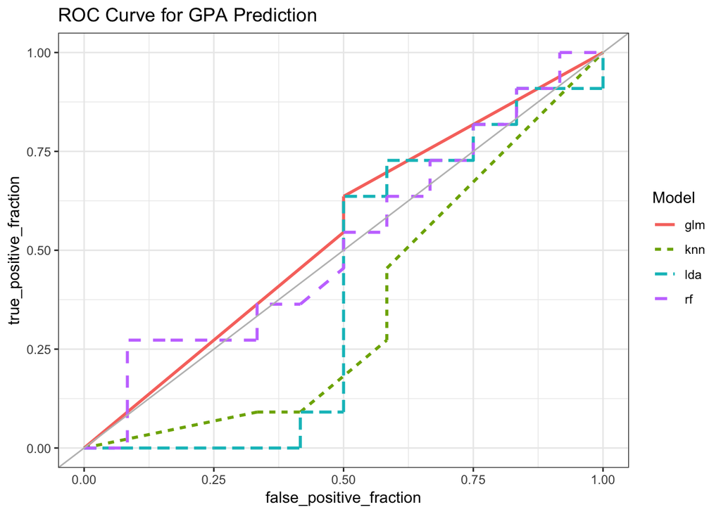

```r
ggplot(data = test, aes(d = D, m = M, color = Model, linetype = Model)) +
  geom_roc(n.cuts = 0) +
  geom_abline(slope = 1, intercept = 0, alpha = 1, color = "grey") +
  theme_bw() +
  ggtitle("ROC Curve for GPA Prediction")
```

From the ROC curves we can see that those models are not very predictive: curves are even below diagnoal line.

Hence, using our food data to predict GPA is not a good idea. It is possible that our sample size is too small; it can also be explained that GPA actually has a weak relationship with food. To check if our machine learning model works, we tried to use the same models to predict weights and hope that it will yield better results compared with GPA.

### Predicting Weights

We used the exact same data and models to predict weights.  
To make results comparable with GPA, here we also convert weight into a binary outcomes (>155 lb).

```r
set.seed(1234)
dat_trsf_nz_im_c <- dat_trsf_nz_im %>% dplyr::mutate(weight = weight >= 155, weight = as.factor(weight))
x.c <- dat_trsf_nz_im_c
y.c <- dat_trsf_nz_im_c[, "weight"]
y.train.c <- y.c[trainIndex]
y.test.c <- y.c[-trainIndex]
x.train.c <- x.c[trainIndex,]
x.test.c <- x.c[-trainIndex,]
x.c <- x.train.c
y.c <- y.train.c
```

We used same models as we did for GPA.

```r
set.seed(123)
fit_knn <- train(weight ~ ., method = "knn", trControl = train.control, data = x.c)
probs1 = predict(fit_knn, newdata = x.test.c, type = "prob")
R1 = roc(y.test.c, probs1[,2])
#plot.roc(R1, col=1, lwd=2, main="ROC curves")
AUC1 = R1$auc
set.seed(123)
fit_glm <- train(weight ~ ., method = "glm", trControl = train.control, data = x.c)
probs2 = predict(fit_glm, newdata = x.test.c, type = "prob")
R2 = roc(y.test.c, probs2[,2])
#plot.roc(R2, col=1, lwd=2, add = TRUE)
AUC2 = R2$auc
set.seed(123)
fit_rf <- train(weight ~ ., method = "rf", trControl = train.control, data = x.c)
probs3 = predict(fit_rf, newdata = x.test.c, type = "prob")
R3 = roc(y.test.c, probs3[,2])
#plot.roc(R3, add = TRUE, col=2, lwd=2)
AUC3 = R3$auc
set.seed(123)
fit_lda <- train(weight ~ ., method = "lda", trControl = train.control, data = x.c)
probs4 = predict(fit_lda, newdata = x.test.c, type = "prob")
R4 = roc(y.test.c, probs4[,2])
#plot.roc(R4, add = TRUE, col=3, lwd=2)
AUC4 = R4$auc
```

```r
test <- data.frame(D = y.test.c, knn = probs1[,2], glm = probs2[,2], rf = probs3[,2], lda = probs4[,2])
#head(test)
test <- test %>% tidyr::gather(key = Model, value = M, -D)
```

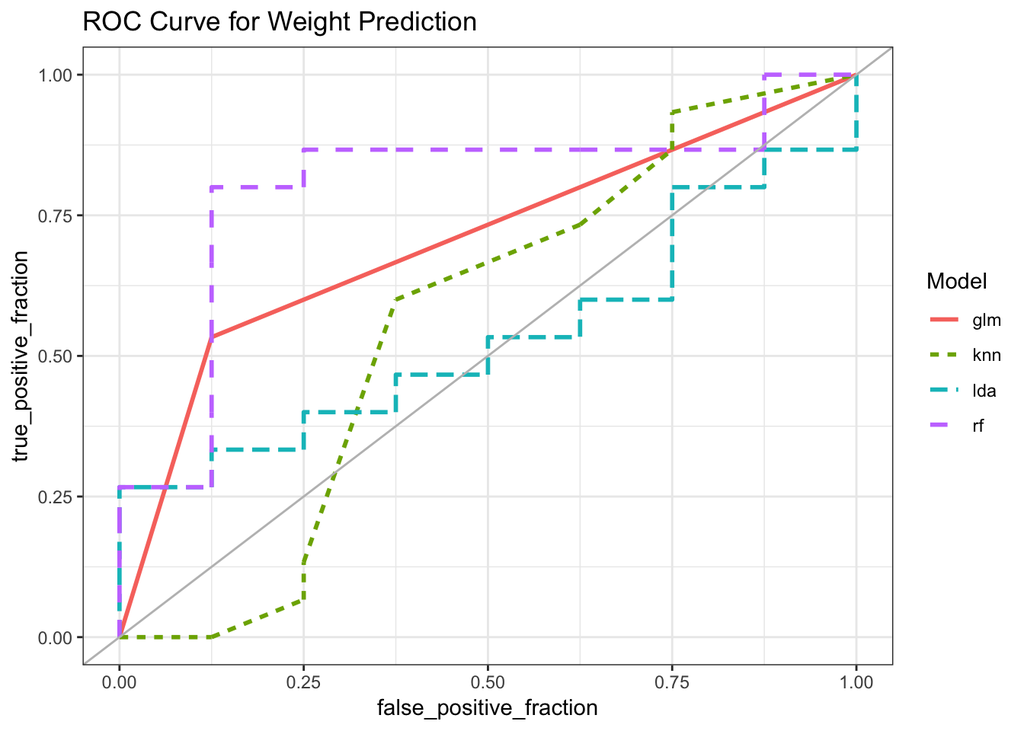

```r
ggplot(data = test, aes(d = D, m = M, color = Model, linetype = Model)) +
  geom_roc(n.cuts = 0) +
  geom_abline(slope = 1, intercept = 0, alpha = 1, color = "grey") +
  theme_bw() +
  ggtitle("ROC Curve for Weight Prediction")
```

We can see that the model performs much better. Therefore, our machine learning methods do work for predicting weights.

## Conclusion

From our interpretation model, a few variables such as father education, students’ preferences toward ethnic food, and exercise frequency are statistically significant predictors for GPA. We then moved on to construct prediction models, because all of our group members are interested to see if what we have are sufficient to predict or classify students’ GPA.

From our prediction model, we could not use our food data to predict GPA (for both continuous GPA and binary GPA). Our machine learning methods face several challenges: small sample size, sparsity, and vigorous categories. However, using the same data and models to predict weights does yield effective prediction. We tend to believe that the bad performance using food to predict GPA is caused by their no association.

## Discussion

Sample size is one of our biggest limitations for this study. Given a small dataset like this, it’s hard to have very satisfying results, especially from machine learning models. Besides, we have concerns about the quality of data because the questionnaires were only collected within one college in the US, so that the data might not be representative enough for all the college students. Also, students may be reluctant to report their true GPA to the questionnaires, which might make our data less reliable. In the future, we may search for more non-parametric methods that work well on small data sets and other methods to deal with missing data.

## References

Diet Quality and Academic Performance (2008) Michelle D. Florence MSc, PDt Mark Asbridge PhD Paul J. Veugelers PhD

Healthier Students Are Better Learners: A Missing Link in School Reforms to Close the Achievement Gap (2011) CHARLES E. BASCH, PhD

Tidier drawings of trees. IEEE Transactions on software Engineering, (2), 223-228 (1981) Reingold, E. M., & Tilford, J. S.

Graph drawing by force‐directed placement. Software: Practice and experience 21(11), 1129-1164 (1991) Fruchterman, T. M., & Reingold, E. M.